# ML pipeline: Binary Classification

## General by hand protocol

C Fanara, March 2021 - rev. October 2021

### 1. Introduction

We use several binary classifiers for benchmark purposes.

In this version the modeling step is iterated 'k' times (k is selectable) for the Scikit learn algorithms.

For now, we focus on the algos as applied to an *individual dataset*, typically for the dev of a use case. Later generalized project will iterate on selected datasets

### 2. Library imports

**Note:** code might be retrieved from the corresponding gitlab project.

```python
import sys, os
import time

import pandas as pd
from pandas import Series
import numpy as np
from sklearn.preprocessing import label_binarize

import matplotlib.pyplot as plt
import seaborn as sns
import plotly.express as px
import plotly.figure_factory as ff

import math  # useful for float NaN
from sklearn.neural_network import MLPClassifier
from sklearn.linear_model import LogisticRegression

from sklearn.neighbors import KNeighborsClassifier
from sklearn.svm import SVC
from sklearn.gaussian_process import GaussianProcessClassifier
from sklearn.gaussian_process.kernels import RBF
from sklearn.tree import DecisionTreeClassifier
from sklearn.ensemble import RandomForestClassifier, AdaBoostClassifier
from sklearn.model_selection import train_test_split
from sklearn.naive_bayes import GaussianNB
from sklearn.discriminant_analysis import QuadraticDiscriminantAnalysis

import xgboost as xgb
import catboost as ctb
from catboost import CatBoostRegressor, Pool, cv

from sklearn.metrics import (accuracy_score, recall_score, f1_score, roc_auc_score, confusion_matrix, matthews_corrcoef, precision_score)
from xgboost import XGBClassifier,plot_importance

# roc and related
from scipy import interp
from sklearn.metrics import roc_auc_score
from sklearn.metrics import plot_roc_curve

# Ipython display facilities
from IPython.display import HTML, display
import tabulate

# interpretation
import shap
```

### 3. Data - import and look

Import DataSet to Panda's DataFrame

```python
# might ask filename with interactive  UI
namef='heart.csv' # the bare name

# read csv using pandas
df = pd.read_csv('~/Documents/Infra_py-ML/classif_data/heart.csv')

# display basic information about the dataframe
print('Dataframe\'s shape: {}\n'.format(df.shape))

# for later (write at the end)
tsk='BiCl'  # others might be: "MuCl"=Multi-class; "Regr"=Regression

df.info()
# describe numeric columns
# df.describe()

df.head(10)
```

```
Dataframe's shape: (303, 14)

<class 'pandas.core.frame.DataFrame'>
RangeIndex: 303 entries, 0 to 302
Data columns (total 14 columns):
 #   Column    Non-Null Count  Dtype
---  ------    --------------  -----
 0   age       303 non-null    int64
 1   sex       303 non-null    int64
 2   cp        303 non-null    int64
 3   trestbps  303 non-null    int64
 4   chol      303 non-null    int64
 5   fbs       303 non-null    int64
 6   restecg   303 non-null    int64
 7   thalach   303 non-null    int64
 8   exang     303 non-null    int64
 9   oldpeak   303 non-null    float64
 10  slope     303 non-null    int64
 11  ca        303 non-null    int64
 12  thal      303 non-null    int64
 13  target    303 non-null    int64
dtypes: float64(1), int64(13)
memory usage: 33.3 KB
```

|  | age | sex | cp | trestbps | chol | fbs | restecg | thalach | exang | oldpeak | slope | ca | thal | target |
| --- | --- | --- | --- | --- | --- | --- | --- | --- | --- | --- | --- | --- | --- | --- |
| 0 | 63 | 1 | 3 | 145 | 233 | 1 | 0 | 150 | 0 | 2.3 | 0 | 0 | 1 | 1 |
| 1 | 37 | 1 | 2 | 130 | 250 | 0 | 1 | 187 | 0 | 3.5 | 0 | 0 | 2 | 1 |
| 2 | 41 | 0 | 1 | 130 | 204 | 0 | 0 | 172 | 0 | 1.4 | 2 | 0 | 2 | 1 |
| 3 | 56 | 1 | 1 | 120 | 236 | 0 | 1 | 178 | 0 | 0.8 | 2 | 0 | 2 | 1 |
| 4 | 57 | 0 | 0 | 120 | 354 | 0 | 1 | 163 | 1 | 0.6 | 2 | 0 | 2 | 1 |
| 5 | 57 | 1 | 0 | 140 | 192 | 0 | 1 | 148 | 0 | 0.4 | 1 | 0 | 1 | 1 |
| 6 | 56 | 0 | 1 | 140 | 294 | 0 | 0 | 153 | 0 | 1.3 | 1 | 0 | 2 | 1 |
| 7 | 44 | 1 | 1 | 120 | 263 | 0 | 1 | 173 | 0 | 0.0 | 2 | 0 | 3 | 1 |
| 8 | 52 | 1 | 2 | 172 | 199 | 1 | 1 | 162 | 0 | 0.5 | 2 | 0 | 3 | 1 |
| 9 | 57 | 1 | 2 | 150 | 168 | 0 | 1 | 174 | 0 | 1.6 | 2 | 0 | 2 | 1 |

```
array([[<AxesSubplot:title={'center':'target'}>]], dtype=object)
```

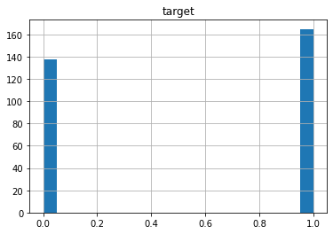

```python
df['target'].value_counts()  # check data balance for target

# just to viz it
df.hist(column=df.columns[-1], bins=20)
```

### 4. Data Profiling: automated

```python
# Quick EDA using panda profiling
from pandas_profiling import ProfileReport
profile_heart = ProfileReport(df, title="heart.csv data" )
profile_heart
```

[interactive chart not shown]

### 5. Modeling

- prepare (features versus target)
- standardize or normalize - if applicable!

#### 5.1 Prepare data

```python
# Prepare training and test sets
target = 'target'

features = df.columns.tolist()
features.remove(target)
print(features, len(features), target)


# Note: may want to check this. else rename as done in other regression script, as below:
X = df[features]
y = df[target]

print(X.shape, y.shape)
```

```
['age', 'sex', 'cp', 'trestbps', 'chol', 'fbs', 'restecg', 'thalach', 'exang', 'oldpeak', 'slope', 'ca', 'thal'] 13 target
(303, 13) (303,)
```

#### 5.2 Standardization / Normalization

#### **warning**: if Variable importance is is run, leave commented

(as with RF we don't standardize in this instance - to be discussed elsewhere)

An agnostic min - max could be used: df_norm = (df-df.min())/(df.max()-df.min())

```python
#X_norm = (X-X.min())/(X.max()-X.min())

#X=X_norm
#X.info()
```

### 6. Feature Importance

Several models provide methods to highlight variables importance, notably Random Forest and XGBoost.

- Random Forest
- xgboost We also instantiate these algorithms in the multi-model protocol in section 7

```python
# define the function Feature importance
def plot_feature_importance(importance,names,model_type):

    # Create arrays from feature importance and feature names
    feature_importance = np.array(importance)
    feature_names = np.array(names)

    # Create a DataFrame using a Dictionary
    data={'feature_names':feature_names,'feature_importance':feature_importance}
    fi_df = pd.DataFrame(data)

    # Sort the DataFrame in order decreasing feature importance
    fi_df.sort_values(by=['feature_importance'], ascending=False,inplace=True)

    # Define size of bar plot
    plt.figure(figsize=(10,8))
    # Plot Searborn bar chart
    sns.barplot(x=fi_df['feature_importance'], y=fi_df['feature_names'])
    # Add chart labels
    plt.title(model_type + 'FEATURE IMPORTANCE')
    plt.xlabel('FEATURE IMPORTANCE')
    plt.ylabel('FEATURE NAMES')
```

```python
# split to perform the fit for the two models below, NB on TRAIN
X_train, X_test, y_train, y_test = train_test_split(X, y, test_size=0.3, random_state=np.random.RandomState(seed=None))  # shuffled but not stratified
X_train.info()
```

```
<class 'pandas.core.frame.DataFrame'>
Int64Index: 212 entries, 70 to 156
Data columns (total 13 columns):
 #   Column    Non-Null Count  Dtype
---  ------    --------------  -----
 0   age       212 non-null    int64
 1   sex       212 non-null    int64
 2   cp        212 non-null    int64
 3   trestbps  212 non-null    int64
 4   chol      212 non-null    int64
 5   fbs       212 non-null    int64
 6   restecg   212 non-null    int64
 7   thalach   212 non-null    int64
 8   exang     212 non-null    int64
 9   oldpeak   212 non-null    float64
 10  slope     212 non-null    int64
 11  ca        212 non-null    int64
 12  thal      212 non-null    int64
dtypes: float64(1), int64(12)
memory usage: 23.2 KB
```

#### 6.1 Random Forest (RF)

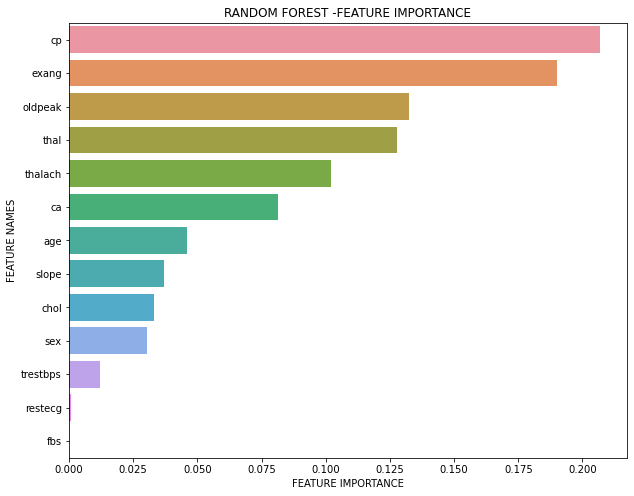

```python
# rf first
RFclf=RandomForestClassifier(max_depth=2, random_state=0)
RFclf.fit(X_train,y_train)

# call it
plot_feature_importance(RFclf.feature_importances_, X_train.columns,'RANDOM FOREST -')
```

#### 6.2 XGBoost

[output not shown]

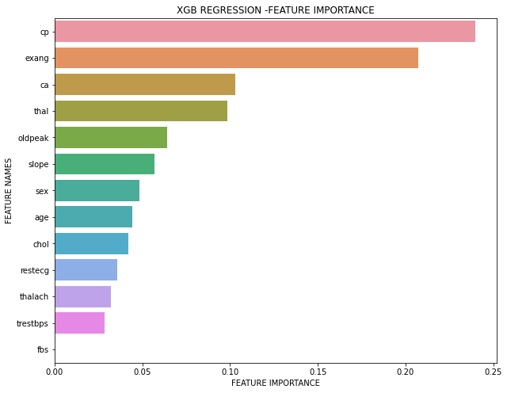

```python
# XGboost
# note the comments on hyperparams: https://www.datacamp.com/community/tutorials/xgboost-in-python
XGBclf = XGBClassifier(use_label_encoder=False, metric='error').fit(X_train, y_train)

# call it
plot_feature_importance(XGBclf.feature_importances_, X_train.columns,'XGB REGRESSION -')
```

#### 6.3 Decide strategy

Suggest:

- establish which one does better
- Whether to drop variables here or use permutation strategies instead

### 7. Generalized train

We use a single function to instantiate all classifiers and a function to specify the metrics Thereafter we repeat all thes classifiers for a specified number of iterations k. At the end we produce:

- a table showing the individual iterations metrics
- an overall metrics outcome by averaging over the k repetitions (aggregation by mean)

#### 7.1 Definitions of metrics

```python
# Generic all-in-one function to train an sklearn estimator and return the corresponding metrics for the training and test sets
def plot_and_compute_classification_metrics(name, estimator, X_train, y_train, X_test, y_test, display_plots=False):


    start = time.time()
    # Train model
    estimator.fit(X_train, y_train)
    stop = time.time()
    exec_t=stop - start

    # Compute classif metrics for both training and test data
    train_predictions = estimator.predict(X_train)
    train_accuracy = accuracy_score(y_train, train_predictions)
    train_precision = precision_score(y_train, train_predictions)
    train_recall = recall_score(y_train, train_predictions)
    train_f1 = f1_score(y_train, train_predictions)
    train_mcc = matthews_corrcoef(y_train, train_predictions)

    test_predictions = estimator.predict(X_test)
    test_accuracy = accuracy_score(y_test, test_predictions)
    test_precision = accuracy_score(y_test, test_predictions)
    test_recall = recall_score(y_test, test_predictions)
    test_f1 = f1_score(y_test, test_predictions)
    test_mcc = matthews_corrcoef(y_test, test_predictions)

    return train_accuracy, train_precision, train_recall, train_f1, train_mcc, test_accuracy, test_precision, test_recall, test_f1, test_mcc, exec_t
```

#### 7.2 The classifier/s

```python
# Instantiate sklearn binary classification estimators. Worth modifying per case (e.g. parameters).

# LogisticRegression - https://scikit-learn.org/stable/modules/generated/sklearn.linear_model.LogisticRegression.html
logreg = LogisticRegression(C=1, penalty='l1', tol=0.01, solver='saga')

# KNearestNeighbors -  https://scikit-learn.org/stable/modules/generated/sklearn.neighbors.KNeighborsClassifier.html
knn = KNeighborsClassifier(3)

# Linear SVM  -  https://scikit-learn.org/stable/modules/generated/sklearn.svm.SVC.html NB kernel parameter, among others - as in the ff rbf
lsvm = SVC(kernel="linear", C=0.025)

# RBF SVM - https://scikit-learn.org/stable/modules/generated/sklearn.svm.SVC.html NB kernel parameter, among others
rbfsvm = SVC(gamma=2, C=1)

# GaussianProcess   - https://scikit-learn.org/stable/modules/generated/sklearn.gaussian_process.GaussianProcessClassifier.html
gp = GaussianProcessClassifier(1.0 * RBF(1.0))

# Decision Tree - https://scikit-learn.org/stable/modules/generated/sklearn.tree.DecisionTreeClassifier.html
tree = DecisionTreeClassifier(max_depth=5)

# Random Forest - https://scikit-learn.org/stable/modules/generated/sklearn.ensemble.RandomForestClassifier.html
forest = RandomForestClassifier(max_depth=5, n_estimators=10, max_features=1)

# Neural network - https://scikit-learn.org/stable/modules/generated/sklearn.neural_network.MLPClassifier.html
neural_net = MLPClassifier(alpha=1)

# Ada Boost - https://scikit-learn.org/stable/modules/generated/sklearn.ensemble.AdaBoostClassifier.html
ada_boost = AdaBoostClassifier()

# Naive Bayes - https://scikit-learn.org/stable/modules/generated/sklearn.naive_bayes.GaussianNB.html
naive_bayes = GaussianNB()

# QDA- https://scikit-learn.org/stable/modules/generated/sklearn.discriminant_analysis.QuadraticDiscriminantAnalysis.html
qda = QuadraticDiscriminantAnalysis()

# xgb_model = XGBClassifier(learning_rate =0.1,
#n_estimators=1000, max_depth=6, min_child_weight=1, gamma=0.5, subsample=0.8, colsample_bytree=0.3, objective= 'binary:logistic', nthread=4, scale_pos_weight=1)

# use same parameters as in variable importance
xgb_model = XGBClassifier(use_label_encoder=False, metric='error')

estimators = {
    "LogisticRegression":logreg,
    "KNearestNeighbors": knn,
    #"LinearSVM": lsvm,
    #"RBFSVM": rbfsvm,
    "GaussianProcess": gp,
    "Decision Tree": tree,
    "Random Forest": forest,
    #"Neural network": neural_net,
    #"Ada Boost": ada_boost,
    #"Naive Bayes": naive_bayes,
    #"QDA": qda,
    "XGBoost":xgb_model
}
```

#### 7.3 Training: Iterating over all the models k-times

```python
k = 10 # magic number of iterations. In effect - seee other protocol where we do Cross validation

# def header of table out of loop.
metrics = [["Estimator", "Train Acc", "Train Precision", "Train Recall", "Train F1", "Train MCC",
           "Test Acc", "Test Precision", "Test Recall", "Test F1", "Test MCC", "Train time"]]

# first element, 0, is header; loop ends at high-1 so, use k+1 (iteration in table shown from '1')
for i in range(1, k+1):

    # avoid identical results by changing seed for each repetition of the lot (take k) np.random.seed(None).
    X_train, X_test, y_train, y_test = train_test_split(X, y, test_size=0.3, random_state=np.random.RandomState(seed=None))  # shuffled but not stratified

    # Train, predict and compute metrics for each estimator
    for name, estimator in estimators.items():
        print("Current estimator: {}".format(name))
        print (i)
        # t-uple added as a list to the table
        trn_acc, trn_prec, trn_rec, trn_f1, trn_mcc, tst_acc, tst_prec, tst_rec, tst_f1, tst_mcc, trn_time = plot_and_compute_classification_metrics(name, estimator, X_train, y_train, X_test, y_test)

        metrics.append([name, trn_acc, trn_prec, trn_rec, trn_f1, trn_mcc, tst_acc, tst_prec, tst_rec, tst_f1, tst_mcc, trn_time ])



# finished estimator loop and the number of times (k) loop, so  uncomment to see global table when debugging:
#display(HTML(tabulate.tabulate(metrics, tablefmt='html', headers='firstrow')))

# Append to dataframe then group by; the 'metr_df' is the dataframe for the global metrics
metr_df = pd.DataFrame(metrics[1:], columns=["Estimator", "Train Acc", "Train Precision", "Train Recall", "Train F1", "Train MCC",
            "Test Acc", "Test Precision", "Test Recall", "Test F1", "Test MCC", "Train time"])
```

[output not shown]

[output not shown]

[output not shown]

[output not shown]

[output not shown]

[output not shown]

[output not shown]

[output not shown]

[output not shown]

[output not shown]

[output not shown]

[output not shown]

[output not shown]

[output not shown]

[output not shown]

[output not shown]

[output not shown]

[output not shown]

[output not shown]

[output not shown]

```python
# Measure also exec time? not easy/precise? in jupyter

k = 5   # several files were run with 2, 5, 10, 15, 20. Standard is 10 - worth experimenting
# caution, loop ends at k-1 and here it starts from 1, so need k+1 iteration!

# def header of table out of loop.
#metrics = [["repetition", "Estimator", "Train Acc", "Train Precision", "Train Recall", "Train F1", "Train MCC",
#           "Test Acc", "Test Precision", "Test Recall", "Test F1", "Test MCC", "Train time"]]

metrics = [["Estimator", "Train Acc", "Train Precision", "Train Recall", "Train F1", "Train MCC",
           "Test Acc", "Test Precision", "Test Recall", "Test F1", "Test MCC", "Train time"]]

# first element, 0, is header and loop ends at high end -1 so, use k+1
for i in range(1, k+1):

    # avoid identical results by changing seed for each repetition of the lot (take k)
    # np.random.seed(None).

    X_train, X_test, y_train, y_test = train_test_split(X, y, test_size=0.3, random_state=np.random.RandomState(seed=None))  # shuffled but not stratified
    # Train, predict and compute metrics for each estimator


    for name, estimator in estimators.items():
        print("Current estimator: {}".format(name))
        print (i)
        # tuple added as a list to the table
        trn_acc, trn_prec, trn_rec, trn_f1, trn_mcc, tst_acc, tst_prec, tst_rec, tst_f1, tst_mcc, trn_time = plot_and_compute_classification_metrics(name, estimator, X_train, y_train, X_test, y_test)

        # metrics.append([name, estimator, trn_acc, trn_prec, trn_rec, trn_f1, trn_mcc, tst_acc, tst_prec, tst_rec, tst_f1, tst_mcc ])
        # metrics.append([i, name, trn_acc, trn_prec, trn_rec, trn_f1, trn_mcc, tst_acc, tst_prec, tst_rec, tst_f1, tst_mcc, trn_time ])
        metrics.append([name, trn_acc, trn_prec, trn_rec, trn_f1, trn_mcc, tst_acc, tst_prec, tst_rec, tst_f1, tst_mcc, trn_time ])

        #print(i)
        #print(trn_acc)
        # metrics.append([name, *(plot_and_compute_classification_metrics(name, estimator, X_train, y_train, X_test, y_test))])


    # issue about too many open windows? for now, brutally close current - or all - window/s
    # plt.close() # current window
    # plt.close('all')  # all open figures.



# finished estimator loop and the number of times (k) loop, so
# 1. may want to see global table for debugging:
#display(HTML(tabulate.tabulate(metrics, tablefmt='html', headers='firstrow')))

# 2. append to dataframe then group by - metr_df is the dataframe for the global stats
#metr_df = pd.DataFrame(metrics[1:], columns=["Repetition","Estimator", "Train Acc", "Train Precision", "Train Recall", "Train F1", "Train MCC",
 #           "Test Acc", "Test Precision", "Test Recall", "Test F1", "Test MCC", "Train time"])
metr_df = pd.DataFrame(metrics[1:], columns=["Estimator", "Train Acc", "Train Precision", "Train Recall", "Train F1", "Train MCC",
            "Test Acc", "Test Precision", "Test Recall", "Test F1", "Test MCC", "Train time"])
```

[output not shown]

```python
# Gather metrics in a common table
#display(HTML(tabulate.tabulate(metrics, tablefmt='html', headers='firstrow')))
```

#### 7.3 Grouping estimators

```python
# group by estimator and stats (avg of the 4 error columns)- aggregation procedure out of groupby operation
aggregations = {
    'Train Acc':'mean',
    'Train Precision':'mean',
    'Train Recall':'mean',
    'Train F1':'mean',
    'Train MCC':'mean',
    'Test Acc':'mean',
    'Test Precision':'mean',
    'Test Recall':'mean',
    'Test F1':'mean',
    'Test MCC':'mean',
    'Train time': 'mean'
}

# Generate the aggregated metric dataframe
#estim_stats=metr_df.groupby('Estimator', as_index=False).agg(aggregations) # 'as_index': to preserve column in dataframe
estim_stats=metr_df.groupby('Estimator').agg(aggregations) # column in dataframe is estimator without the number
```

```python
# Gather metrics in a common table
display(HTML(tabulate.tabulate(metrics, tablefmt='html', headers='firstrow')))
```

[output not shown]

```python
# Gather metrics in a common table
# display(HTML(tabulate.tabulate(metrics, tablefmt='html', headers='firstrow')))
```

```python
## k-averages of previous tables
estim_stats.sort_values(by="Test Acc", ascending=False, inplace=True)

display(HTML(tabulate.tabulate(estim_stats, tablefmt='html', headers=metrics[0])))
```

| Estimator | Train Acc | Train Precision | Train Recall | Train F1 | Train MCC | Test Acc | Test Precision | Test Recall | Test F1 | Test MCC | Train time |
| --- | --- | --- | --- | --- | --- | --- | --- | --- | --- | --- | --- |
| Random Forest | 0.918868 | 0.900043 | 0.959799 | 0.928816 | 0.837268 | 0.802198 | 0.802198 | 0.890074 | 0.824941 | 0.608662 | 0.0210848 |
| XGBoost | 1 | 1 | 1 | 1 | 1 | 0.796703 | 0.796703 | 0.846697 | 0.813409 | 0.593044 | 0.0892971 |
| Decision Tree | 0.941038 | 0.939117 | 0.956314 | 0.947106 | 0.88189 | 0.752747 | 0.752747 | 0.807956 | 0.774187 | 0.508276 | 0.00304365 |
| LogisticRegression | 0.701887 | 0.703119 | 0.797097 | 0.746926 | 0.391271 | 0.673626 | 0.673626 | 0.79457 | 0.717317 | 0.353476 | 0.00622525 |
| KNearestNeighbors | 0.795283 | 0.807411 | 0.826042 | 0.816291 | 0.585205 | 0.608791 | 0.608791 | 0.681486 | 0.644604 | 0.215828 | 0.00281019 |
| GaussianProcess | 1 | 1 | 1 | 1 | 1 | 0.573626 | 0.573626 | 0.621677 | 0.602832 | 0.143521 | 0.986668 |

### 8. Interpretation

Aside of general refs on interpretation and SHAP we resot to the docs: https://nbviewer.org/github/chaitanyakasaraneni/SHAP_EBM_Examples/blob/main/SHAP%20Example.ipynb https://shap.readthedocs.io/en/latest/example_notebooks/tabular_examples/tree_based_models/Front%20page%20example%20%28XGBoost%29.html

Recall the method in practice:

1. generate an explainer, here we use RF model on the TRAIN
2. obtain the shap values by applying it to the TEST
3. choose the plot, often summary or individual barplot/s or waterfall - see below

Not ehtat we could simply take the model ranked first from the previous table, PERHAPS automatically. For now, to *show how it works* we just re-train using the best model by hand. Note that some algorithms are not yet available in the shap library.

Also, in todo: We did not save write the models we just got the metrics table; consider saving he model (certainly when closer to prod we'll have that!)

#### 8.1 Use best model to fit Test instance

```python
# rf
#RandomForestClassifier(max_depth=5, n_estimators=10, max_features=1)
RFmod=RandomForestClassifier(max_depth=5, max_features=1, n_estimators=10, random_state=10)
RFmod.fit(X_train,y_train)
```

```
RandomForestClassifier(max_depth=5, max_features=1, n_estimators=10,
                       random_state=10)
```

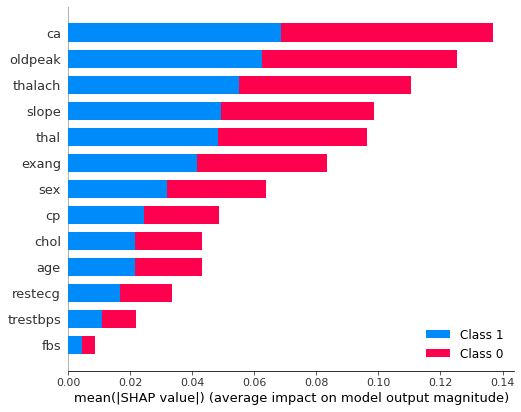

```python
# shap_values = shap.TreeExplainer(GPmod).shap_values(X_train)  # get error: "Model type not yet supported by TreeExplainer"
shap_values = shap.TreeExplainer(RFmod).shap_values(X_test)

shap.summary_plot(shap_values, X_test, plot_type="bar")
```

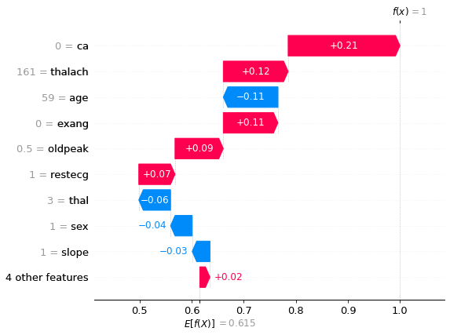

```python
explainer = shap.Explainer(RFmod.predict, X_test)

# shap_values = explainer(X_test) # note this step mayu be long to run! below we sample on 100 elements only (notice time duration)
shap_values = explainer(X_test[:100])
shap.plots.waterfall(shap_values[0])
```

#### 8.2 Explain the Waterefall

Ref. docs: https://shap.readthedocs.io/en/latest/example_notebooks/api_examples/plots/waterfall.html The waterfall plot shows how the shap values of the individual features are added to the base value in order to generate a final prediction. "The bottom of the waterfall plot starts as the expected value of the model output E[f(x)]- here 0.6. Then each row shows how the positive (red) or negative (blue) contribution of each feature shifts this value from the expected model output over the background dataset to the model output for this prediction. Note this is a single prediction, hence the effect of a variable like - say - 'thal' (here it is ) can be seen globally using a scatter plot - as per ref. above - where we show the shap values versus tghe variable values - see plot below

NOTES:

- Note we passed just shap_values[0].
- Questioning additiviness & order of additions: if linear, it does not matter but if not...)

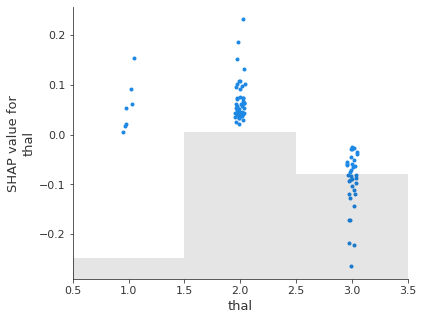

```python
# scatter to show shap of the variable thal (thalassemia) versus its values
# note thal is discrete - categorical 0 - see appendix - data dictionary
shap.plots.scatter(shap_values[:,"thal"])
```

#### 8.3. Explain beeswarm and importance plots

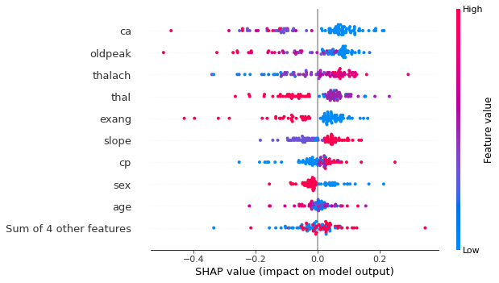

```python
shap.plots.beeswarm(shap_values)
```

Beeswarm plot is designed to display how the top features in a dataset impact the model’s output. Each instance is represented by a single dot on each feature row. The x position of the dot is determined by the SHAP value (shap_values.value[instance,feature]) of the feature, and dots “pile up” along each feature row to show density. Color is used to display the original value of a feature (shap_values.data[instance,feature]).

To do: may want to complete viz (and discussion!) with decision and 'force plots'

### 9. Write/save model results

(The estimators metrics)

```python
# Use the same file path. So to have the results always traceable, code a table filename with:
# - task: Regr, BiCl, MuCl (regression, binaryClassif, MultiClass)
# - dataset name - perhaps abbreviated? (ex. "wine", "rest", "energy", etc)
# - number of repetitions, k
# - name of original dataset

fnout= 'T_'+ tsk + '_' + str(k) + namef
fnout

# Write the file - the metr_df - as a csv
# might want to put a header with the settings
# also might want the models themselves - or the copy of the cell with the link to scikit - for repeatability?
# estim_stats.to_csv is written in active folder
estim_stats.to_csv(fnout)
```

### 10. More on metrics

(Leave as exercise)

#### Todo (I): Plot the ROC and show AUC

This should be done with the final model chosen

#### Todo (II): plot learning curve

Same as above

#### Todo( III): package in a script

The idea is to transform the notebook (Nb) for experimentation into a production package. We will go per grades, not necessarily in this order:

1. the Nb becomes a script where the input file will be acquired from the user
2. the choice as whether to pre-select/eliminate some of the metrics depending on the task
3. the pre-selection/cut of some of the estimators - e.g. select from a list

Hint: check nbconveret or generate script automatically

### APPENDIX: Data dictionary

**Features**